# Drain the Swamp

Abby Kaplan

May 27, 2018

Our party was at a lake. We wanted to reach the dragon’s lair at the bottom of the lake, but we were reluctant to swim that far. We decided to put a teleportation circle at the bottom of the lake, and link it to a teleportation circle at the prison where our friend was being held. We were able to keep the teleportation circles open for only 36 seconds.

**Question:** How deep will the lake be after 36 seconds?

# Size of the lake

My first thought was to model the lake as a spherical cap, but the equations for the volume of a spherical cap are hard to work with. Let’s try something else.

Instead, we model the lake as the frustum of a right circular cone (i.e., a cone with the tip chopped off). The small end of the frustum (with radius $r$) is the bottom of the lake; the large end (with radius $R$) is the initial surface of the lake.

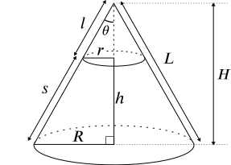

We can relate the volume $V$ of the frustum, its height $h$, and its radii $r$ and $R$ as follows:

$$V = \frac{\pi h}{3} (R^2 + Rr + r^2)$$

The initial dimensions of the lake, as supplied by the DM, were as follows:

$$V_i = 31,000 \mbox{ ft}^3 = 880 \mbox{ m}^3$$

$$h_i = 50 \mbox{ ft} = 15 \mbox{ m}$$

$$R_i = 20 \mbox{ ft} = 6.1 \mbox{ m}$$

Solving for $r_i$, we obtain

$$\frac{\pi h_i}{3}r_i^2 + \frac{\pi h_iR_i}{3}r_i + \frac{\pi h_iR_i^2}{3} - V = 0$$

Applying the quadratic equation yields $r_i = 2.2 \mbox{ m}$.

As water drains from the lake, $r$ remains constant, but $V$, $h$, and $R$ all change. However, the angle $\theta$ also remains constant, and this allows us to express $R$ as a function of $r_i$ and $h$, thus eliminating one variable. If $\theta$ is the angle of a right triangle with sides $h$ and $R - r$, then

$$\tan{\theta} = \frac{R - r}{h} = \frac{R_i - r_i}{h_i} = 0.26$$

(Incidentally, this means that $\theta = 14^{\circ}$. The lake has very steep sides.) Since $\theta$ is constant, then at any point in time, $R = r_i + h\tan{\theta}$.

# Speed of water draining from the lake

According to the internet, the rate of volume flow from an opening in a container of liquid is

$$v = C_vC_cA\sqrt{2gh}$$

where $v$ is the rate of volume flow from the container, $C_v$ is the velocity coefficient of water ($0.98$), $A$ is the area of the opening ($2.3 \mbox{ m}^2$ for a five-foot square), $g$ is the acceleration due to gravity ($9.8 \mbox{ m}/\mbox{s}^2$), and $h$ is the height of the water above the opening (in our case, the depth of the lake). $C_c$ is the “contraction coefficient”: 0.62 for an opening with a sharp edge, 0.97 for an opening with a rounded edge. Let’s go with $C_c = 0.9$.

$v$ is a function of $h$, which is itself a function of $V$. If we can express $v$ as a function of $V$, then we have a first-order differential equation. As a first step, let’s try to express $h$ as a function of $V$. If we substitute $r_i + h\tan{\theta}$ for $R$ in the volume equation above, we obtain the following cubic equation for $h$:

$$(\frac{\pi \tan^2{\theta}}{3})h^3 + (\pi r_i \tan{\theta})h^2 + (\pi r_i^2)h - V = 0$$

$$0.07h^3 + 1.8h^2 + 15h - V = 0$$

The cubic equation has an analytical solution, but it’s horrendous. We could try plugging that solution back into the volume flow equation, but I have no hope of solving that differential equation analytically. On to numerical methods!

# Modeling water draining from the lake

Let $H(V)$ be the horrendous function that gives the height $h$ of the lake as a function of its volume. I’ll let R do all those calcuations.

Let’s divide our 36-second period into 1-second intervals. During each interval, the volume flow is constant and depends on the volume at the beginning of the interval.

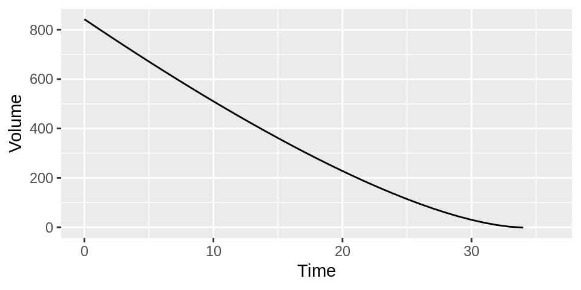

How do things look different if our intervals are 0.1 seconds long instead of 1 second?

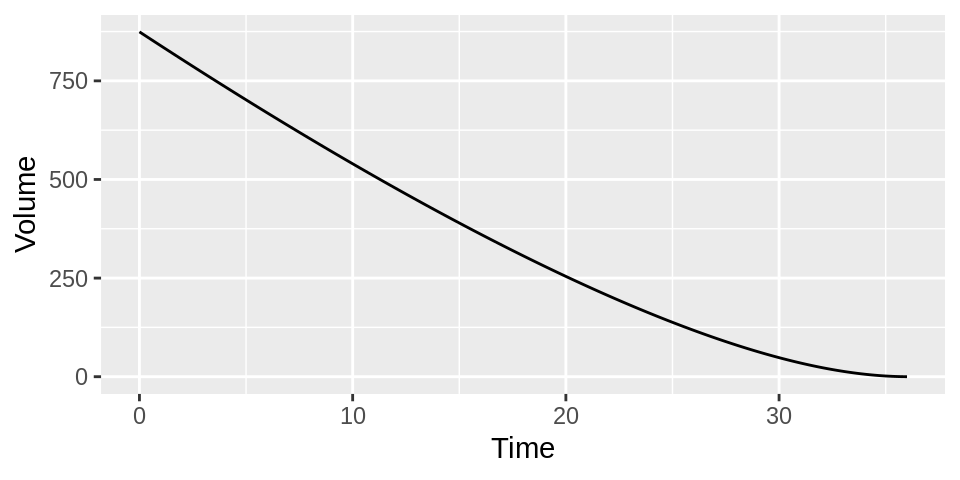

What about 0.01 seconds?

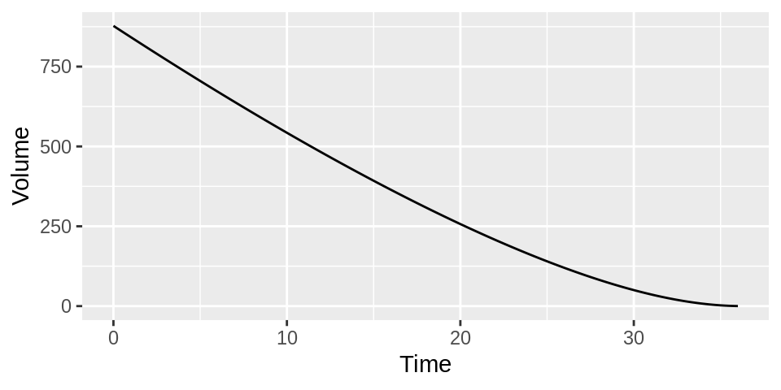

As the size of the intervals decreases, our simulation becomes more accurate. Clearly, we are converging on a total time of about 36 seconds to fully drain the lake.

**Preliminary conclusion:** We should have pretty much drained the whole lake in 36 seconds.

# But wait – how sharp is the edge of the opening?

If the hole of the teleportation circle has a sharp edge rather than a rounded one, then $C_c$ should be smaller, and therefore the water should drain more slowly. We don’t know exactly what kind of hole the teleportation circle would make, but a sharp edge actually seems pretty reasonable. What does the simulation with 0.01-second intervals look like if we posit $C_c = 0.62$?

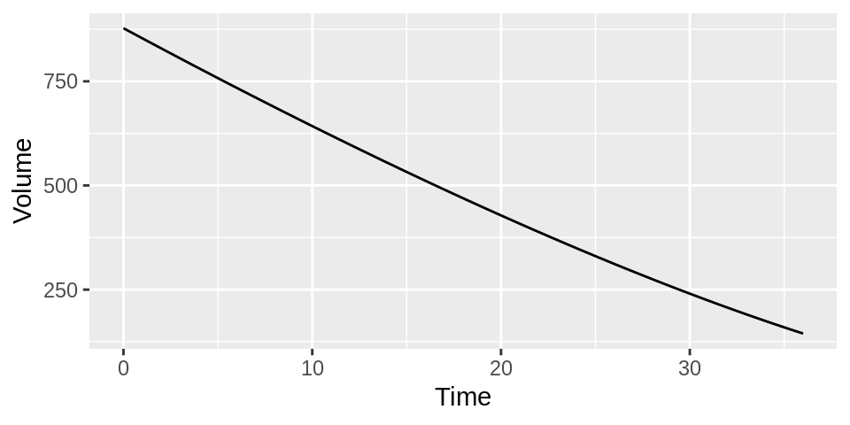

The lake doesn’t fully drain in 36 seconds. Its final volume is $140 \mbox{ m}^3$, which translates to a depth of $5.5 \mbox{ m}$. That’s close to what we did during the actual session.

**Final conclusion:** We got things about right! Yay.